# Practical 1A - R fundamentals

Liege microbiome workshop

Author

David Barnett

Published

November 24, 2025

## 1 Introduction 👋

### 1.1 Learning goals 🧠

- Using Quarto
- Reading tabular data
- Inspecting data
- Joining data frames
- Mutating data frames

### 1.2 Getting started 🚀

In this workshop we will use an online version of [RStudio](https://posit.co/download/rstudio-desktop/) - via [posit.cloud](https://posit.cloud/spaces/583413!)

1. [Sign up for a free posit.cloud account](https://posit.cloud/spaces/583413!)  
   (use a GitHub or Google account if you already have one of these)
2. Check your email for a link to join the posit.cloud space for this course
3. Click on the **Liege-microbiome** project - this will start RStudio
4. Go to **Files** (look bottom right) > click folder `practical-1` > open file `practical-1A-notebook.qmd`

### 1.3 Using Quarto 📝

We will write code and notes in [Quarto](https://r4ds.hadley.nz/quarto) `.qmd` documents, e.g. `practical-1A-notebook.qmd`

#### **Write some notes:**

You can write normal text for notes, e.g. your intentions, hypotheses, observations, etc.

To edit your Quarto notebooks in RStudio you can use “[Visual](https://quarto.org/docs/visual-editor/)” editor mode, or the “Source” mode.

*Toggle between modes at the top left. Visual editor is easier for beginners, but Source mode shows how the Quarto file truly looks (it only contains [markdown](https://quarto.org/docs/authoring/markdown-basics.html) text, but RStudio adds formatting in Visual mode).*

#### **Write and run code:**

You can write code and comments in “chunks” - like the one below.

Run a chunk by clicking the green play button in the corner of the chunk

```r
# This is a comment, because it starts with the # symbol
print("This line is code, try to run it!")
```

Insert a code chunk with `Ctrl`+`Alt`+`I` (Windows) or `Cmd`+`Option`+`I` (Mac).

```r
# You can also run code with keyboard shortcuts!
print("Run this one line with Ctrl + Enter, or Cmd + Enter on Mac")
print("or run a whole chunk with Ctrl/Cmd + SHIFT + Enter")
```

You can run all previous chunks by clicking the other button in the corner of the chunk.

## 2 Load R packages 📦

It is a good idea to load all the packages you need at the top of your notebook.

```r
# `readxl` is for reading data from Excel files
library(readxl)
```

```r
# `writexl` is for writing data to a new Excel file
library(writexl) # we'll use this at the end
```

```r
# the `here` package makes specifying file locations easier
library(here)
```

```r
# `tidyverse` is a collection of several packages
library(tidyverse) # (dplyr, ggplot2, and others)
```

## 3 Reading data 📂

How do we read a table of data from a file, e.g. an Excel file?

```r
# give your objects short but informative names!
meta <- read_excel(path = here("data/papa2012/papa2012_metadata.xlsx"), na = "NA")
meds <- read_excel(here("data/papa2012/papa2012_metadata.xlsx"), sheet = "treatment")
```

**Tip 1: Projects and portable file paths**

There are multiple ways to tell R where to find the data files for a project.

**Projects + relative paths**

👍 **The best way** 👍

1. For each data analysis project you do, create a separate folder for that project, and keep all relevant code and data inside that folder.
2. RStudio also offers additional convenient features for organisation with [RStudio Projects](https://r4ds.hadley.nz/workflow-scripts.html#rstudio-projects)!
3. Using the R package called `here` you can easily specify the location of your data using file paths relative to the project folder. The `here` package offers one important function, also called `here()`

```r
# this will work anywhere! (anywhere that the project folder is moved or copied)
meta <- read_excel(path = here("data/papa2012/papa2012_metadata.xlsx"), na = "NA")
```

This is reliable and portable! 🤩 If you share the entire project folder with a collaborator (e.g. as a zip file or via github) then this code will work on their computer without needing any changes!

**Absolute paths**

😐 **Easy but limiting** 😐

1. An absolute path (also known as a full path) can be used to specify where a file is on your own computer.
2. This will work okay, but only if you never move your files, and never change computer…
3. Using absolute paths makes it **inconvenient** to share your project or work collaboratively. 🙁

```r
# this works on my machine, but it won't work anywhere else!
meta <- read_excel(
  path = "/Users/david/Documents/teaching/workshops/Liege-microbiome/data/papa2012/papa2012_metadata.xlsx",
  na = "NA"
)
```

**setwd + relative paths**

🤷 **Commonly used but still problematic** 🤷

- You can use paths relative to the *working directory* set with `setwd("/an/absolute/path/on/your/computer")`, BUT:
1. setwd still uses an absolute path, so it is still not portable!
2. setwd does not work in notebooks, which reset working directory every chunk
3. Prof. Jenny Bryan might set your computer on fire! 🖥️🔥 ([read why here](https://www.tidyverse.org/blog/2017/12/workflow-vs-script/))

```r
# this works on my machine, but it won't work anywhere else!
setwd("/Users/david/Documents/teaching/workshops/Liege-microbiome")
meta <- read_excel(path = "data/papa2012/papa2012_metadata.xlsx", na = "NA")
```

## 4 Inspecting data

### 4.1 Look at the tables 👀

Start by printing the metadata data frame, like this:

```r
meta
```

```
# A tibble: 90 × 10
   ID    sample case_control diagnosis activity active   gender ethnicity
   <chr> <chr>  <chr>        <chr>     <chr>    <chr>    <chr>  <chr>
 1 099A  099-AX Case         UC        severe   active   female White
 2 199A  199-AX Control      Other     control  control  female Other
 3 062B  062-BZ Case         CD        mild     active   male   White
 4 194A  194-AZ Case         UC        mild     active   male   White
 5 166A  166-AX Case         UC        severe   active   female Black
 6 219A  219-AX Case         UC        inactive inactive female <NA>
 7 132A  132-AX Case         CD        mild     active   female White
 8 026A  026-AX Case         UC        mild     active   male   White
 9 102A  102-AZ Control      Other     control  control  male   White
10 140A  140-AX Control      Other     control  control  female White
# ℹ 80 more rows
# ℹ 2 more variables: family_history <chr>, age_years <dbl>
```

**Tip 2: What is (in) this object?**

**dataframes & tibbles**

A dataframe is the standard class of object for holding rectangular data (tables) in your R environment.

Columns of a dataframe can hold vectors of different classes, e.g. chr and int (characters and integers)

(In contrast, a matrix can only hold one type of data!)

```r
example_df <- data.frame(alphabet = LETTERS, numbers = 1:26)
```

Try `View(example_df)` in the Console - but not in a Quarto doc chunk

A tibble is just a dataframe, but with a concise print format, useful!

```r
example_tbl <- as_tibble(example_df)
example_tbl
```

```
# A tibble: 26 × 2
   alphabet numbers
   <chr>      <int>
 1 A              1
 2 B              2
 3 C              3
 4 D              4
 5 E              5
 6 F              6
 7 G              7
 8 H              8
 9 I              9
10 J             10
# ℹ 16 more rows
```

**vector classes?**

Each column in a dataframe/tibble can be on of the following types of vector object

- **numeric**: real numbers, e.g., `c(7.5, -2.301, 0.666)`.
- **integer**: whole numbers, e.g., `c(9L, 4L, -123L)`.
- **logical**: Boolean values, e.g., `c(TRUE, FALSE)`.
- **character**: strings of text, e.g., `c("no", "yes", "unsure")`.
- **factor**: categories with fixed levels, e.g., `factor(c("no", "yes", "unsure"))`.

```r
table(meta$family_history, useNA = "ifany")
```

```
  fhx nofhx  <NA>
   25    54    11
```

```r
table(meta$age_years, useNA = "ifany")
```

```
 3  4  5  6  7  8  9 10 11 12 13 14 15 16 17 18 19 20 21 24
 2  3  5  1  2  5  5  4  6 10  6  9  7  7  4  4  5  3  1  1
```

### 4.2 Summarise 📋

You can count the number of times a category occurs, similar to the table function.

```r
meta %>% count(diagnosis)
```

```
# A tibble: 3 × 2
  diagnosis     n
  <chr>     <int>
1 CD           23
2 Other        24
3 UC           43
```

Or count combinations of categories.

```r
meta %>% count(family_history, diagnosis)
```

```
# A tibble: 9 × 3
  family_history diagnosis     n
  <chr>          <chr>     <int>
1 fhx            CD            8
2 fhx            Other         4
3 fhx            UC           13
4 nofhx          CD           12
5 nofhx          Other        14
6 nofhx          UC           28
7 <NA>           CD            3
8 <NA>           Other         6
9 <NA>           UC            2
```

Or compute other summary statistics.

```r
meta %>% summarise(age_mean = mean(age_years), age_sd = sd(age_years))
```

```
# A tibble: 1 × 2
  age_mean age_sd
     <dbl>  <dbl>
1     12.6   4.65
```

Or compute grouped summary statistics

```r
meta %>% summarise(age_mean = mean(age_years), age_sd = sd(age_years), .by = diagnosis)
```

```
# A tibble: 3 × 3
  diagnosis age_mean age_sd
  <chr>        <dbl>  <dbl>
1 UC           13.8    4.26
2 Other         9.08   4.30
3 CD           14.1    3.84
```

### 4.3 Visualise 📊

R’s base graphics can be used to quickly summarise data distributions.

**Histogram**

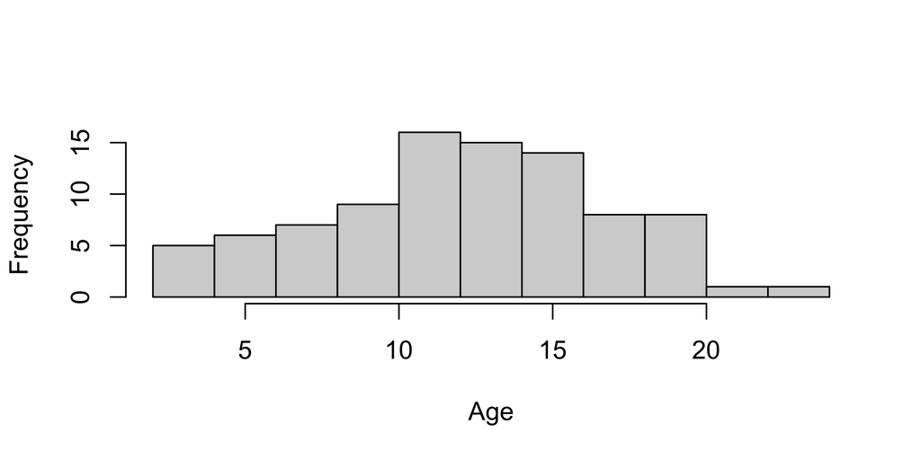

```r
meta$age_years %>% hist(breaks = 10, main = NULL, xlab = "Age")
```

**Bar chart**

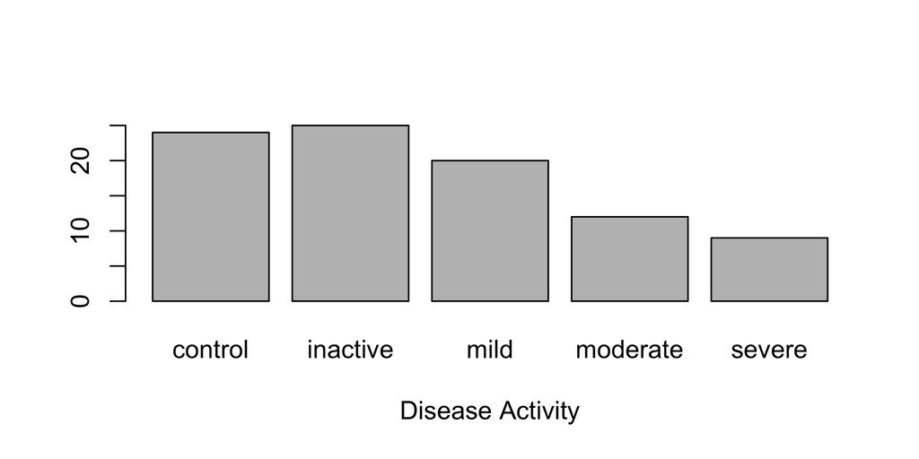

```r
meta$activity %>% table() %>% barplot(xlab = "Disease Activity")
```

ggplot2 is a popular and powerful plotting package.

**Histogram**

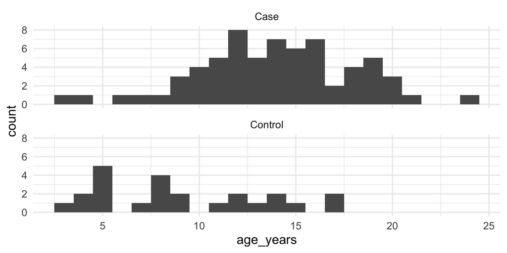

```r
ggplot(meta) +
  geom_histogram(aes(age_years), binwidth = 1) +
  facet_wrap(~case_control, ncol = 1) +
  theme_minimal()
```

**Bar chart**

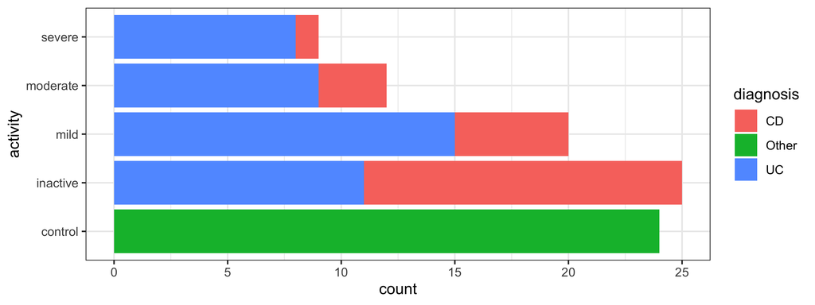

```r
ggplot(meta) +
  geom_bar(aes(y = activity, fill = diagnosis)) +
  theme_bw()
```

**Tip 3: `ggsave` to save your plots? 🦸📊💾**

- Viewing your plots in RStudio is okay for practice
- But don’t copy paste them to save them, as there is a much better way!

```r
# Assign your plot to an R object
plot_practice_bars <- ggplot(meta) +
  geom_bar(aes(y = activity, fill = diagnosis)) +
  ggtitle("Practice bar chart") +
  theme_bw()

# create a folder for figures
dir.create(here("practical-1/figs"), showWarnings = FALSE)

# Write the plot to a file, with ggsave
ggsave(
  plot = plot_practice_bars,
  filename = here("practical-1/figs/practice-barchart.png"),
  width = 6, height = 3, units = "in", dpi = 300
)
```

**Be sure to carefully adjust the sizing and resolution of your plots for your paper or presentation!**

**Tip 4: Sizing plots in Quarto reports 📏📊📄**

- Again, viewing your plots in the RStudio is only okay for practice.
- If you’re using Quarto reports, you can specify figure size and resolution in each chunk

e.g.

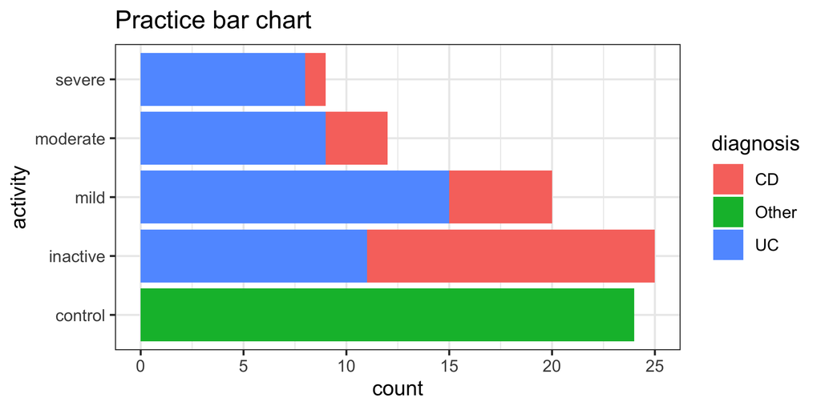

````markdown
```{r}
#| fig-width: 6
#| fig-height: 3

ggplot(meta) +
  geom_bar(aes(y = activity, fill = diagnosis)) +
  ggtitle("Practice bar chart") +
  theme_bw()
```
````

**Tip 5: Become a ggplot2 wizard 🧙**

We will use ggplot2 throughout much of this workshop.

It is a powerful and flexible tool, but it takes practice to learn the details.

**Resources**

Links to good resources for learning ggplot2

- [R 4 Data Science book](https://r4ds.hadley.nz/visualize.html) - intro to plots in R
- [R Graphics Cookbook](https://r-graphics.org/) - quick practical guide
- [R graph gallery](https://r-graph-gallery.com/) - ideas and example code
- [ggplot2 website](https://ggplot2.tidyverse.org/reference/index.html) - a reference manual
- [ggplot2 book](https://ggplot2-book.org/) - for a thorough grounding
- [Cedric Scherer’s blog](https://www.cedricscherer.com/2019/08/05/a-ggplot2-tutorial-for-beautiful-plotting-in-r/) - tutorial/examples
- [Metaprogramming, Advanced R](https://adv-r.hadley.nz/metaprogramming.html) - experts only 🤯

**Example**

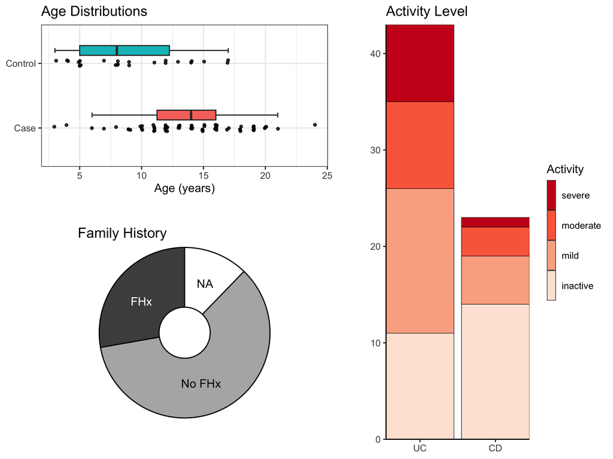

```r
library(patchwork)

plot_list <- list()

# age boxplot
plot_list$box <- meta %>%
  ggplot(aes(y = case_control, x = age_years)) +
  geom_boxplot(
    mapping = aes(fill = case_control),
    width = 0.15, staplewidth = 0.5, outliers = FALSE,
    position = position_nudge(y = 0.2),
    show.legend = FALSE
  ) +
  geom_jitter(height = 0.05, width = 0.1, alpha = 0.8, size = 1) +
  labs(y = NULL, x = "Age (years)", title = "Age Distributions") +
  theme_bw() +
  theme(plot.margin = margin(b = 20, r = 20))

# plot_list$box

# family history piechart
plot_list$pie <- meta %>%
  ggplot(aes(y = 1, fill = family_history)) +
  geom_bar(position = "stack", colour = "black") +
  scale_fill_manual(
    values = c(fhx = "grey30", nofhx = "grey70"),
    na.value = "white", guide = "none"
  ) +
  annotate("text", x = I(pi / 8), y = I(0.25), label = "NA") +
  annotate("text", x = I(0.9 * pi), y = I(0.25), label = "No FHx") +
  annotate("text", x = I(1.7 * pi), y = I(0.25), label = "FHx", colour = "white") +
  labs(tag = "Family History") +
  labs(x = NULL, y = NULL) +
  coord_radial(expand = FALSE, inner.radius = 0.3) +
  theme_void() +
  theme(plot.tag.location = "panel", plot.margin = margin(t = 10))

# plot_list$pie

# activity barchart
plot_list$bar <- meta %>%
  ggplot(aes(
    x = diagnosis,
    fill = factor(activity, c("severe", "moderate", "mild", "inactive"))
  )) +
  geom_bar(colour = "black", linewidth = 0.2) +
  scale_x_discrete(limits = c("UC", "CD")) +
  scale_fill_brewer(name = "Activity", palette = "Reds", direction = -1) +
  labs(title = "Activity Level", x = NULL, y = NULL) +
  coord_cartesian(ylim = c(0, NA), expand = FALSE) +
  theme_classic() +
  theme(
    plot.margin = margin(l = 20),
    legend.key.height = unit(1, "cm"), legend.key.width = unit(3, "mm")
  )

# plot_list$bar

# assemble with patchwork
wrap_plots(
  A = plot_list$box, C = plot_list$bar,
  B = plot_list$pie, guides = "collect",
  design =
    "AAC
 AAC
 BBC
 BBC
 BBC"
)
```

## 5 Joining data 🟧+️🟪

Often, your data are not all in one table. For example, there were two sheets of data in the metadata Excel file, which we stored in the dataframe objects `meta` and `meds`

**meta**

The main dataframe `meta` contains most of the data about each patient:

```r
meta
```

```
# A tibble: 90 × 10
   ID    sample case_control diagnosis activity active   gender ethnicity
   <chr> <chr>  <chr>        <chr>     <chr>    <chr>    <chr>  <chr>
 1 099A  099-AX Case         UC        severe   active   female White
 2 199A  199-AX Control      Other     control  control  female Other
 3 062B  062-BZ Case         CD        mild     active   male   White
 4 194A  194-AZ Case         UC        mild     active   male   White
 5 166A  166-AX Case         UC        severe   active   female Black
 6 219A  219-AX Case         UC        inactive inactive female <NA>
 7 132A  132-AX Case         CD        mild     active   female White
 8 026A  026-AX Case         UC        mild     active   male   White
 9 102A  102-AZ Control      Other     control  control  male   White
10 140A  140-AX Control      Other     control  control  female White
# ℹ 80 more rows
# ℹ 2 more variables: family_history <chr>, age_years <dbl>
```

**meds**

The second dataframe `meds` contains medications info for the IBD cases:

```r
meds
```

```
# A tibble: 67 × 4
   ID    diagnosis immunosuppression_level medication
   <chr> <chr>     <chr>                   <chr>
 1 048A  UC        level0                  mesalamine only
 2 119A  UC        level0                  mesalamine only
 3 120D  UC        level0                  mesalamine only
 4 192A  UC        level0                  mesalamine only
 5 215A  UC        level0                  mesalamine only
 6 216A  UC        level0                  mesalamine only
 7 233A  CD        level0                  mesalamine only
 8 009A  UC        level1                  steroids
 9 035A  UC        level1                  steroids
10 038A  UC        level1                  steroids
# ℹ 57 more rows
```

`dplyr` provides functions to “join” dataframes together, using shared variables.

```r
all_meta <- left_join(meta, meds)
```

By default the join function will perform a “natural” join using all shared variables. For greater control you can specify a “key” variable, or set of variables, that should be used.

```r
# this should do the same thing as the natural join shown above
all_meta <- left_join(meta, meds, by = join_by(ID, diagnosis))
```

What happened with the Control group? (remember they were not present in `meds`!)

Inspect the `all_meta` dataframe to find out! e.g. `View(all_meta)`

**Tip 6: Learn the ways of the join 🪄**

A natural left join is the most common join you will need.

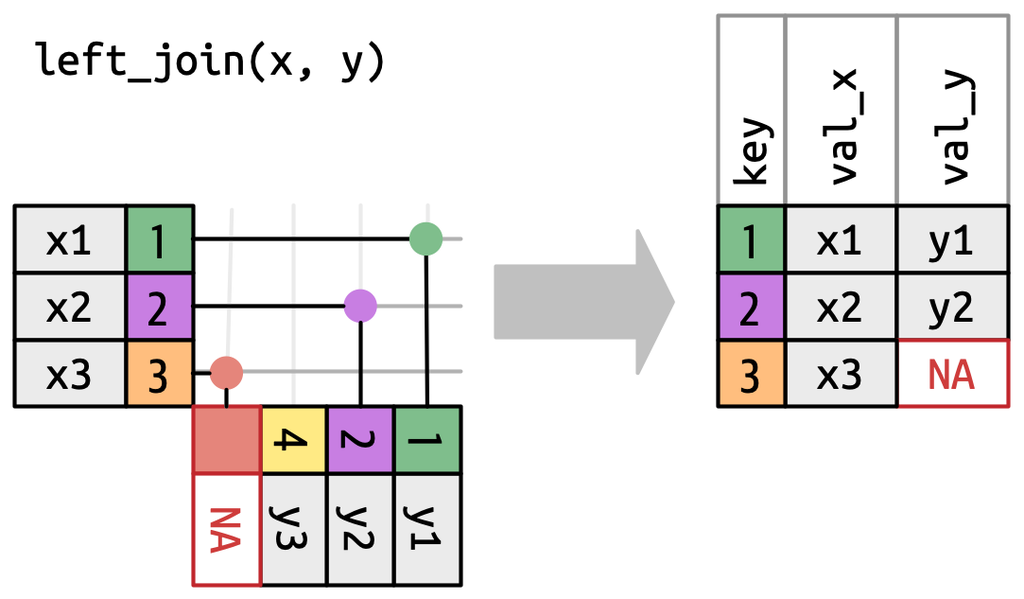

But there are many other useful possibilities, e.g.

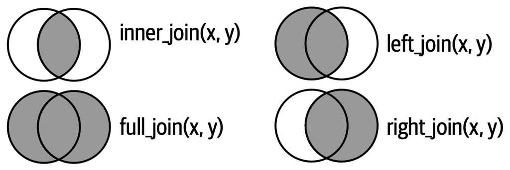

Learn more at:

- This R4DS [online book chapter](https://r4ds.hadley.nz/joins)
- This dplyr [website article](https://dplyr.tidyverse.org/articles/two-table.html)

## 6 Mutating data 🧬?

Often, you need to modify your variables, or create new ones.

### 6.1 Modify and assign

1. Apply a function/transformation to an existing variable (or multiple variables).
2. Assign the result to a new variable, or overwrite the original variable.

**Base R 🤖**

For simple transformations you can easily do this with base R.

```r
# create a logical variable, TRUE if patient has family history of IBD
all_meta$ibd_fhx <- all_meta$family_history == "fhx"

# always check the result is what you expected!
all_meta[, c("ID", "family_history", "ibd_fhx")]
```

```
# A tibble: 90 × 3
   ID    family_history ibd_fhx
   <chr> <chr>          <lgl>
 1 099A  nofhx          FALSE
 2 199A  <NA>           NA
 3 062B  nofhx          FALSE
 4 194A  nofhx          FALSE
 5 166A  <NA>           NA
 6 219A  nofhx          FALSE
 7 132A  nofhx          FALSE
 8 026A  nofhx          FALSE
 9 102A  fhx            TRUE
10 140A  nofhx          FALSE
# ℹ 80 more rows
```

**dplyr::mutate 👽**

The `mutate` function from dplyr is great for making multiple or complex transformations. You refer to variables without repeating the name of the dataframe. It is as if you are working “inside” the dataframe.

```r
# this is equivalent to the previous block
all_meta <- all_meta %>% mutate(ibd_fhx = family_history == "fhx")

# check the result again
all_meta %>% select(ID, family_history, ibd_fhx)
```

```
# A tibble: 90 × 3
   ID    family_history ibd_fhx
   <chr> <chr>          <lgl>
 1 099A  nofhx          FALSE
 2 199A  <NA>           NA
 3 062B  nofhx          FALSE
 4 194A  nofhx          FALSE
 5 166A  <NA>           NA
 6 219A  nofhx          FALSE
 7 132A  nofhx          FALSE
 8 026A  nofhx          FALSE
 9 102A  fhx            TRUE
10 140A  nofhx          FALSE
# ℹ 80 more rows
```

### 6.2 Temporary or persistent?

We can convert character string variables to factor variables to specify an ordering of their levels (e.g. for plotting).

**Temporary ⚡**

You can temporarily mutate a dataframe and use the result. This is easy with pipes.

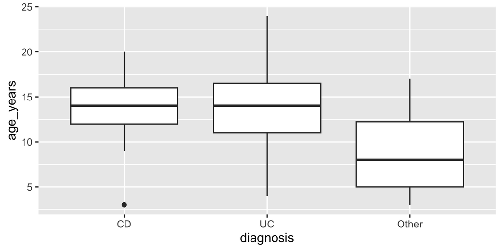

```r
all_meta %>%
  mutate(diagnosis = factor(diagnosis, levels = c("CD", "UC", "Other"))) %>%
  ggplot(aes(diagnosis, age_years)) +
  geom_boxplot()
```

Notice this did NOT persistently modify the diagnosis variable, it is still “character” class.

```r
class(all_meta$diagnosis) # no persistent changes, diagnosis is still character!
```

```
[1] "character"
```

**Persistent 🪨**

`mutate` returns a modified dataframe and you must assign this to an object for changes to persist.

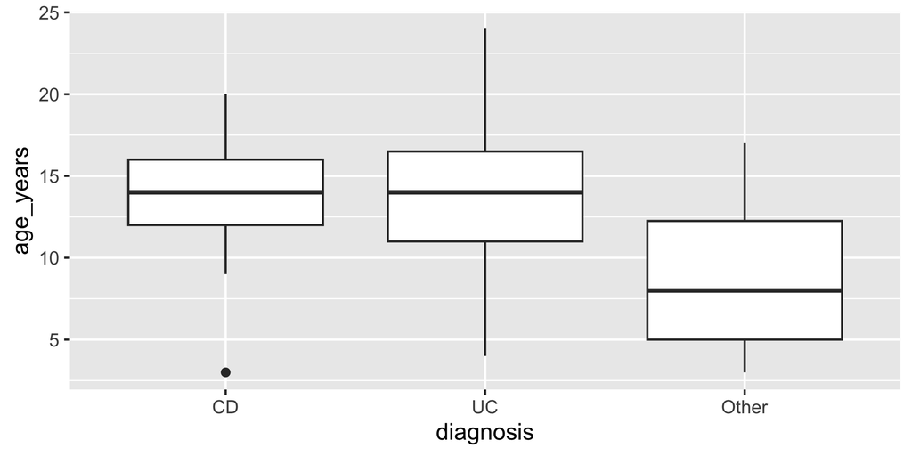

```r
all_meta <- all_meta %>% mutate(diagnosis = factor(diagnosis, c("CD", "UC", "Other")))
all_meta %>% ggplot(aes(diagnosis, age_years)) +
  geom_boxplot()
```

```r
class(all_meta$diagnosis)
```

```
[1] "factor"
```

### 6.3 More mutation

We need to clean up the medication history.

```r
table(all_meta$medication, useNA = "if")
```

```
                abx           abx, imsp                imsp     mesalamine only
                  1                   3                  14                   7
           steroids       steroids, abx steroids, abx, imsp      steroids, imsp
                 12                   4                  11                  11
               <NA>
                 27
```

```r
table(all_meta$immunosuppression_level, useNA = "if")
```

```
level0 level1 level2 level3 level4   none   <NA>
     7     16     18     11     10      4     24
```

We have NAs for the medication for all the Controls. We know they had “none”, so let’s first indicate that. We will also replace Controls’ immunosuppression_level NA values with “none”.

```r
all_meta <- all_meta %>% mutate(
  medication = if_else(case_control == "Control", true = "none", false = medication),
  immunosuppression_level = if_else(case_control == "Control", true = "none", false = immunosuppression_level)
)

# check the result!
all_meta %>% select(ID, case_control, medication, immunosuppression_level)
```

```
# A tibble: 90 × 4
   ID    case_control medication          immunosuppression_level
   <chr> <chr>        <chr>               <chr>
 1 099A  Case         steroids, imsp      level3
 2 199A  Control      none                none
 3 062B  Case         steroids, imsp      level3
 4 194A  Case         steroids            level1
 5 166A  Case         abx                 none
 6 219A  Case         abx, imsp           level3
 7 132A  Case         steroids, imsp      level2
 8 026A  Case         steroids, abx, imsp level4
 9 102A  Control      none                none
10 140A  Control      none                none
# ℹ 80 more rows
```

We now want logical variables indicating if the patient recently had antibiotics (abx), steroids, or other immunosuppressive drugs (imsp).

```r
all_meta <- all_meta %>% mutate(
  abx = str_detect(medication, "abx"),
  steroids = str_detect(medication, "steroids"),
  imsp_other = str_detect(medication, "imsp"),
  imsp_any = steroids | imsp_other
)

# check the result!
# all_meta %>% select(case_control, medication, abx, steroids, imsp_other, imsp_any)
```

For the character variables with more than two values, we can convert them to factors, to encode our preferred ordering of their levels.

In R stats methods, the 1st level of a factor is often used as the reference level by default. So we should keep this in mind, and typically set control levels as the 1st factor level. We can always temporarily change this for plots.

```r
all_meta <- all_meta %>% mutate(
  diagnosis = factor(diagnosis, c("Other", "CD", "UC")),
  active = factor(active, c("control", "inactive", "active")),
  activity = factor(activity, c("control", "inactive", "mild", "moderate", "severe"))
)
```

Now you do the same for `immunosuppression_level`! Don’t forget to check the result

**Click for solution**

```r
all_meta <- all_meta %>% mutate(
  immunosuppression_level = factor(x = immunosuppression_level, c(
    "none", "level0", "level1", "level2", "level3", "level4"
  ))
)
```

```r
all_meta %>% select(diagnosis, activity, immunosuppression_level)
```

```
# A tibble: 90 × 3
   diagnosis activity immunosuppression_level
   <fct>     <fct>    <fct>
 1 UC        severe   level3
 2 Other     control  none
 3 CD        mild     level3
 4 UC        mild     level1
 5 UC        severe   none
 6 UC        inactive level3
 7 CD        mild     level2
 8 UC        mild     level4
 9 Other     control  none
10 Other     control  none
# ℹ 80 more rows
```

## 7 Save your progress 💾

Let’s save the `all_meta` dataframe in three formats: Excel, CSV, and RDS, all within a folder called “processed” inside the “data” folder.

First, we’ll create the “processed” directory.

```r
output_path <- here("data", "papa2012", "processed")
dir.create(output_path, showWarnings = FALSE)
```

Then we write an excel file, using the `write_xlsx` function from the `writexl` package.

```r
write_xlsx(all_meta, here(output_path, "all_metadata.xlsx"))
```

CSV files are a common format for storing tabular data. We use the `write_csv` function from the `readr` package.

```r
write_csv(all_meta, here(output_path, "all_metadata.csv"))
```

RDS files are R’s native format for saving single R objects. They preserve data types and structures, making them ideal for saving and loading a variety of R objects.

```r
saveRDS(all_meta, here(output_path, "all_metadata.rds"))
```

## 8 Next! ⏩

- We have recapped some R fundamentals and introduced the sample metadata.
- Next we will start working with microbiome data!
- Click here: https://david-barnett.github.io/Liege-microbiome/practical-1/web/practical1B-instructions.html

## 9 Session info

For reproducibility, it is useful to record the packages and versions used in your analyses. This is easy to do with `sessioninfo::session_info()`.

[session information not shown]